# Exo 2 : Distribution des langues au Bénin en 2002 (AFC-CAH)

Author

France Guérin-Pace

## Introduction

Le but de cet exercice est :

1. De montrer les commandes R permettant de réaliser une Analayse Factorielle des Correspondances (AFC) sous R
2. D’apprendre à commenter les résultats de cette AFC

En préalable à cet exercice il est indispensable d’avoir bien maîtrisé les fondements théoriques des deux méthodes d’AFC et de CAH en métrique du chi-2. Ces enseignements n’étant pas détaillés sur le présent site, nous recommandons de se reporter au MOOC de cours de François Husson en suivant les liens suivants

- [Cours sur l’AFC](https://husson.github.io/MOOC_AnaDo/AFC.html)
- [Cours sur la classification](https://husson.github.io/MOOC_AnaDo/classif.html)

## Données

On charge le tableau de données “LAN-BENIN-2002-NIV1.csv” décrivant pour chacun des 12 départements du Bénin le nombre de personnes parlant une langue ou un groupe de langues en 2002. Les chiffres sont exprimés en milliers et les valeurs arrondies.

```
   admin1Pcod     admin1 Fon Adja Yoruba Bariba Peul Ottamari Yoa Dendi Autres
1        BJ01    Alibori  16    0     10    177   94        5   0   214      5
2        BJ02    Atacora  27    0     16    280   38      143   5    33      5
3        BJ03 Atlantique 489   56     80     40   32       24  16    32     32
4        BJ04     Borgou  51    7     58    275  210       29  14    65     14
5        BJ05   Collines 150   11    273      0   32       27  27     0     16
6        BJ06     Couffo  52  441     26      0    5        0   0     0      0
7        BJ07      Donga  18    0     11     21   35        0 112   151      4
8        BJ08   Littoral 319   40    120     53   20       27   7    33     47
9        BJ09       Mono  76  227     22      4   18        4   0     4      7
10       BJ10      Oueme 519   22    110      0   29       22   0     7     22
11       BJ11    Plateau  85   28    273      0   12        8   0     0      0
12       BJ12        Zou 546   24     18      0    6        0   0     0      6
```

### Profils en ligne (Nij/Ni.)

On crée un tableau de **profils en ligne** (tabrow) qui donne la répartition des langues parlées pour les différents départements. La somme de chaque ligne est égale à 100%

Profils en ligne (Nij/Ni.) en %

|  | Fon | Adja | Yoruba | Bariba | Peul | Ottamari | Yoa | Dendi | Autres | Sum |
| --- | --- | --- | --- | --- | --- | --- | --- | --- | --- | --- |
| Alibori | 3.1 | 0.0 | 1.9 | 34.0 | 18.0 | 1.0 | 0.0 | 41.1 | 1.0 | 100 |
| Atacora | 4.9 | 0.0 | 2.9 | 51.2 | 6.9 | 26.1 | 0.9 | 6.0 | 0.9 | 100 |
| Atlantique | 61.0 | 7.0 | 10.0 | 5.0 | 4.0 | 3.0 | 2.0 | 4.0 | 4.0 | 100 |
| Borgou | 7.1 | 1.0 | 8.0 | 38.0 | 29.0 | 4.0 | 1.9 | 9.0 | 1.9 | 100 |
| Collines | 28.0 | 2.1 | 50.9 | 0.0 | 6.0 | 5.0 | 5.0 | 0.0 | 3.0 | 100 |
| Couffo | 9.9 | 84.2 | 5.0 | 0.0 | 1.0 | 0.0 | 0.0 | 0.0 | 0.0 | 100 |
| Donga | 5.1 | 0.0 | 3.1 | 6.0 | 9.9 | 0.0 | 31.8 | 42.9 | 1.1 | 100 |
| Littoral | 47.9 | 6.0 | 18.0 | 8.0 | 3.0 | 4.1 | 1.1 | 5.0 | 7.1 | 100 |
| Mono | 21.0 | 62.7 | 6.1 | 1.1 | 5.0 | 1.1 | 0.0 | 1.1 | 1.9 | 100 |
| Oueme | 71.0 | 3.0 | 15.0 | 0.0 | 4.0 | 3.0 | 0.0 | 1.0 | 3.0 | 100 |
| Plateau | 20.9 | 6.9 | 67.2 | 0.0 | 3.0 | 2.0 | 0.0 | 0.0 | 0.0 | 100 |
| Zou | 91.0 | 4.0 | 3.0 | 0.0 | 1.0 | 0.0 | 0.0 | 0.0 | 1.0 | 100 |

### Profils en colonne (Nij/N.j)

On crée un tableau de **profils en colonne** (tabcol) qui donne pour chaque langue parlée la répartition au sein de chacun des départements. La somme de chaque colonne est égale à 100%:

Profils en colonnes (Nij/N.j) en %

|  | Fon | Adja | Yoruba | Bariba | Peul | Ottamari | Yoa | Dendi | Autres |
| --- | --- | --- | --- | --- | --- | --- | --- | --- | --- |
| Alibori | 0.7 | 0.0 | 1.0 | 20.8 | 17.7 | 1.7 | 0.0 | 39.7 | 3.2 |
| Atacora | 1.1 | 0.0 | 1.6 | 32.9 | 7.2 | 49.5 | 2.8 | 6.1 | 3.2 |
| Atlantique | 20.8 | 6.5 | 7.9 | 4.7 | 6.0 | 8.3 | 8.8 | 5.9 | 20.3 |
| Borgou | 2.2 | 0.8 | 5.7 | 32.4 | 39.5 | 10.0 | 7.7 | 12.1 | 8.9 |
| Collines | 6.4 | 1.3 | 26.8 | 0.0 | 6.0 | 9.3 | 14.9 | 0.0 | 10.1 |
| Couffo | 2.2 | 51.5 | 2.6 | 0.0 | 0.9 | 0.0 | 0.0 | 0.0 | 0.0 |
| Donga | 0.8 | 0.0 | 1.1 | 2.5 | 6.6 | 0.0 | 61.9 | 28.0 | 2.5 |
| Littoral | 13.6 | 4.7 | 11.8 | 6.2 | 3.8 | 9.3 | 3.9 | 6.1 | 29.7 |
| Mono | 3.2 | 26.5 | 2.2 | 0.5 | 3.4 | 1.4 | 0.0 | 0.7 | 4.4 |
| Oueme | 22.1 | 2.6 | 10.8 | 0.0 | 5.5 | 7.6 | 0.0 | 1.3 | 13.9 |
| Plateau | 3.6 | 3.3 | 26.8 | 0.0 | 2.3 | 2.8 | 0.0 | 0.0 | 0.0 |
| Zou | 23.3 | 2.8 | 1.8 | 0.0 | 1.1 | 0.0 | 0.0 | 0.0 | 3.8 |
| Sum | 100.0 | 100.0 | 100.0 | 100.0 | 100.0 | 100.0 | 100.0 | 100.0 | 100.0 |

### Profil total (Nij/N..)

On crée le tableau tabtot en divisant l’effectif de chaque case par l’effectif total du tableau. La somme de toutes les cases du tableau est égale à 100%.

Part du total (Nij/N..) en %

|  | Fon | Adja | Yoruba | Bariba | Peul | Ottamari | Yoa | Dendi | Autres | Sum |
| --- | --- | --- | --- | --- | --- | --- | --- | --- | --- | --- |
| Alibori | 0.2 | 0.0 | 0.1 | 2.6 | 1.4 | 0.1 | 0.0 | 3.2 | 0.1 | 7.7 |
| Atacora | 0.4 | 0.0 | 0.2 | 4.1 | 0.6 | 2.1 | 0.1 | 0.5 | 0.1 | 8.1 |
| Atlantique | 7.2 | 0.8 | 1.2 | 0.6 | 0.5 | 0.4 | 0.2 | 0.5 | 0.5 | 11.8 |
| Borgou | 0.8 | 0.1 | 0.9 | 4.1 | 3.1 | 0.4 | 0.2 | 1.0 | 0.2 | 10.7 |
| Collines | 2.2 | 0.2 | 4.0 | 0.0 | 0.5 | 0.4 | 0.4 | 0.0 | 0.2 | 7.9 |
| Couffo | 0.8 | 6.5 | 0.4 | 0.0 | 0.1 | 0.0 | 0.0 | 0.0 | 0.0 | 7.7 |
| Donga | 0.3 | 0.0 | 0.2 | 0.3 | 0.5 | 0.0 | 1.7 | 2.2 | 0.1 | 5.2 |
| Littoral | 4.7 | 0.6 | 1.8 | 0.8 | 0.3 | 0.4 | 0.1 | 0.5 | 0.7 | 9.8 |
| Mono | 1.1 | 3.4 | 0.3 | 0.1 | 0.3 | 0.1 | 0.0 | 0.1 | 0.1 | 5.3 |
| Oueme | 7.7 | 0.3 | 1.6 | 0.0 | 0.4 | 0.3 | 0.0 | 0.1 | 0.3 | 10.8 |
| Plateau | 1.3 | 0.4 | 4.0 | 0.0 | 0.2 | 0.1 | 0.0 | 0.0 | 0.0 | 6.0 |
| Zou | 8.1 | 0.4 | 0.3 | 0.0 | 0.1 | 0.0 | 0.0 | 0.0 | 0.1 | 8.9 |
| Sum | 34.7 | 12.6 | 15.0 | 12.6 | 7.8 | 4.3 | 2.7 | 8.0 | 2.3 | 100.0 |

## Analyse bivariée

Pour mesurer la relation entre les deux variables qualitatives , on effectue un test du chi-2. La p.value obtenue (< 0.01) indique une forte dépendance entre les deux variables.

```
    Pearson's Chi-squared test

data:  tab
X-squared = 12332, df = 88, p-value < 2.2e-16
```

### Valeurs théoriques

On calcule les valeurs théoriques attendues si il y avait indépendance entre les deux variables département et langues

Valeurs théoriques N*ij = (Nij x N.j) /N..

|  | Fon | Adja | Yoruba | Bariba | Peul | Ottamari | Yoa | Dendi | Autres | Sum |
| --- | --- | --- | --- | --- | --- | --- | --- | --- | --- | --- |
| Alibori | 180.7 | 65.9 | 78.3 | 65.4 | 40.9 | 22.2 | 13.9 | 41.5 | 12.2 | 521 |
| Atacora | 189.7 | 69.2 | 82.2 | 68.7 | 42.9 | 23.4 | 14.6 | 43.6 | 12.8 | 547 |
| Atlantique | 277.8 | 101.3 | 120.3 | 100.6 | 62.8 | 34.2 | 21.4 | 63.8 | 18.7 | 801 |
| Borgou | 250.8 | 91.4 | 108.6 | 90.8 | 56.7 | 30.9 | 19.3 | 57.6 | 16.9 | 723 |
| Collines | 185.9 | 67.8 | 80.5 | 67.3 | 42.0 | 22.9 | 14.3 | 42.7 | 12.5 | 536 |
| Couffo | 181.8 | 66.3 | 78.7 | 65.8 | 41.1 | 22.4 | 14.0 | 41.7 | 12.2 | 524 |
| Donga | 122.1 | 44.5 | 52.9 | 44.2 | 27.6 | 15.0 | 9.4 | 28.0 | 8.2 | 352 |
| Littoral | 231.0 | 84.2 | 100.1 | 83.6 | 52.2 | 28.4 | 17.8 | 53.0 | 15.5 | 666 |
| Mono | 125.6 | 45.8 | 54.4 | 45.5 | 28.4 | 15.5 | 9.7 | 28.8 | 8.4 | 362 |
| Oueme | 253.6 | 92.4 | 109.8 | 91.8 | 57.3 | 31.2 | 19.5 | 58.2 | 17.1 | 731 |
| Plateau | 140.8 | 51.3 | 61.0 | 51.0 | 31.8 | 17.3 | 10.9 | 32.3 | 9.5 | 406 |
| Zou | 208.1 | 75.9 | 90.1 | 75.3 | 47.1 | 25.6 | 16.0 | 47.8 | 14.0 | 600 |
| Sum | 2348.0 | 856.0 | 1017.0 | 850.0 | 531.0 | 289.0 | 181.0 | 539.0 | 158.0 | 6769 |

### Résidus absolus

On calcule dans le tableau tabres la différence entre les effectifs attendus (théoriques) et les effectifs observées.

Résidus absolus (Nij - N*ij)

|  | Fon | Adja | Yoruba | Bariba | Peul | Ottamari | Yoa | Dendi | Autres | Sum |
| --- | --- | --- | --- | --- | --- | --- | --- | --- | --- | --- |
| Alibori | -164.7 | -65.9 | -68.3 | 111.6 | 53.1 | -17.2 | -13.9 | 172.5 | -7.2 | 0 |
| Atacora | -162.7 | -69.2 | -66.2 | 211.3 | -4.9 | 119.6 | -9.6 | -10.6 | -7.8 | 0 |
| Atlantique | 211.2 | -45.3 | -40.3 | -60.6 | -30.8 | -10.2 | -5.4 | -31.8 | 13.3 | 0 |
| Borgou | -199.8 | -84.4 | -50.6 | 184.2 | 153.3 | -1.9 | -5.3 | 7.4 | -2.9 | 0 |
| Collines | -35.9 | -56.8 | 192.5 | -67.3 | -10.0 | 4.1 | 12.7 | -42.7 | 3.5 | 0 |
| Couffo | -129.8 | 374.7 | -52.7 | -65.8 | -36.1 | -22.4 | -14.0 | -41.7 | -12.2 | 0 |
| Donga | -104.1 | -44.5 | -41.9 | -23.2 | 7.4 | -15.0 | 102.6 | 123.0 | -4.2 | 0 |
| Littoral | 88.0 | -44.2 | 19.9 | -30.6 | -32.2 | -1.4 | -10.8 | -20.0 | 31.5 | 0 |
| Mono | -49.6 | 181.2 | -32.4 | -41.5 | -10.4 | -11.5 | -9.7 | -24.8 | -1.4 | 0 |
| Oueme | 265.4 | -70.4 | 0.2 | -91.8 | -28.3 | -9.2 | -19.5 | -51.2 | 4.9 | 0 |
| Plateau | -55.8 | -23.3 | 212.0 | -51.0 | -19.8 | -9.3 | -10.9 | -32.3 | -9.5 | 0 |
| Zou | 337.9 | -51.9 | -72.1 | -75.3 | -41.1 | -25.6 | -16.0 | -47.8 | -8.0 | 0 |
| Sum | 0.0 | 0.0 | 0.0 | 0.0 | 0.0 | 0.0 | 0.0 | 0.0 | 0.0 | 0 |

### Chi2 par cellule

Chi_2 = (Nij-N*ij)2 / N*ij

|  | Fon | Adja | Yoruba | Bariba | Peul | Ottamari | Yoa | Dendi | Autres | Sum |
| --- | --- | --- | --- | --- | --- | --- | --- | --- | --- | --- |
| Alibori | 150.1 | 65.9 | 59.6 | 190.3 | 69.1 | 13.4 | 13.9 | 717.4 | 4.2 | 1283.8 |
| Atacora | 139.6 | 69.2 | 53.3 | 650.1 | 0.6 | 613.0 | 6.3 | 2.6 | 4.7 | 1539.3 |
| Atlantique | 160.5 | 20.3 | 13.5 | 36.5 | 15.1 | 3.0 | 1.4 | 15.8 | 9.5 | 275.6 |
| Borgou | 159.2 | 78.0 | 23.6 | 373.8 | 414.3 | 0.1 | 1.5 | 1.0 | 0.5 | 1051.8 |
| Collines | 6.9 | 47.6 | 460.0 | 67.3 | 2.4 | 0.7 | 11.2 | 42.7 | 1.0 | 639.8 |
| Couffo | 92.6 | 2119.2 | 35.3 | 65.8 | 31.7 | 22.4 | 14.0 | 41.7 | 12.2 | 2435.0 |
| Donga | 88.8 | 44.5 | 33.2 | 12.2 | 2.0 | 15.0 | 1118.1 | 539.5 | 2.2 | 1855.4 |
| Littoral | 33.5 | 23.2 | 4.0 | 11.2 | 19.9 | 0.1 | 6.6 | 7.6 | 63.6 | 169.7 |
| Mono | 19.6 | 717.4 | 19.3 | 37.8 | 3.8 | 8.5 | 9.7 | 21.4 | 0.2 | 837.7 |
| Oueme | 277.9 | 53.7 | 0.0 | 91.8 | 14.0 | 2.7 | 19.5 | 45.0 | 1.4 | 506.1 |
| Plateau | 22.1 | 10.6 | 736.8 | 51.0 | 12.4 | 5.0 | 10.9 | 32.3 | 9.5 | 890.6 |
| Zou | 548.5 | 35.5 | 57.7 | 75.3 | 35.8 | 25.6 | 16.0 | 47.8 | 4.6 | 846.9 |
| Sum | 1699.3 | 3284.9 | 1496.3 | 1663.1 | 621.0 | 709.6 | 1229.1 | 1514.7 | 113.6 | 12331.6 |

### Contributions au chi2

En divisant la valeur du Chi2 pour chaque cellule par le Chi2 global, on obtient la contribution de chaque cellule au Chi2 global. Plus la contribution d’une cellule est élevée, plus le département et la langue qui correspondent à cette cellule s’éloignent de l’effectif attendu en cas d’indépendance entre les deux variables.

% du chi_2 total du tableau (contribution)

|  | Fon | Adja | Yoruba | Bariba | Peul | Ottamari | Yoa | Dendi | Autres | Sum |
| --- | --- | --- | --- | --- | --- | --- | --- | --- | --- | --- |
| Alibori | 1.22 | 0.53 | 0.48 | 1.54 | 0.56 | 0.11 | 0.11 | 5.82 | 0.03 | 10.41 |
| Atacora | 1.13 | 0.56 | 0.43 | 5.27 | 0.00 | 4.97 | 0.05 | 0.02 | 0.04 | 12.48 |
| Atlantique | 1.30 | 0.16 | 0.11 | 0.30 | 0.12 | 0.02 | 0.01 | 0.13 | 0.08 | 2.23 |
| Borgou | 1.29 | 0.63 | 0.19 | 3.03 | 3.36 | 0.00 | 0.01 | 0.01 | 0.00 | 8.53 |
| Collines | 0.06 | 0.39 | 3.73 | 0.55 | 0.02 | 0.01 | 0.09 | 0.35 | 0.01 | 5.19 |
| Couffo | 0.75 | 17.18 | 0.29 | 0.53 | 0.26 | 0.18 | 0.11 | 0.34 | 0.10 | 19.75 |
| Donga | 0.72 | 0.36 | 0.27 | 0.10 | 0.02 | 0.12 | 9.07 | 4.38 | 0.02 | 15.05 |
| Littoral | 0.27 | 0.19 | 0.03 | 0.09 | 0.16 | 0.00 | 0.05 | 0.06 | 0.52 | 1.38 |
| Mono | 0.16 | 5.82 | 0.16 | 0.31 | 0.03 | 0.07 | 0.08 | 0.17 | 0.00 | 6.79 |
| Oueme | 2.25 | 0.44 | 0.00 | 0.74 | 0.11 | 0.02 | 0.16 | 0.37 | 0.01 | 4.10 |
| Plateau | 0.18 | 0.09 | 5.97 | 0.41 | 0.10 | 0.04 | 0.09 | 0.26 | 0.08 | 7.22 |
| Zou | 4.45 | 0.29 | 0.47 | 0.61 | 0.29 | 0.21 | 0.13 | 0.39 | 0.04 | 6.87 |
| Sum | 13.78 | 26.64 | 12.13 | 13.49 | 5.04 | 5.75 | 9.97 | 12.28 | 0.92 | 100.00 |

## Analyse Factorielle des Correspondances (AFC)

Elle est facile à réaliser à l’aide de la fonction **CA()** du package`FactomineR`:

### Valeurs propres

La valeur propre associée à un axe donne la part de variance expliquée par l’axe ou l’information contenue dans le tableau de données, prise en compte par l’axe. Les quatre premiers axes expliquent 91.12% de l’information totale.

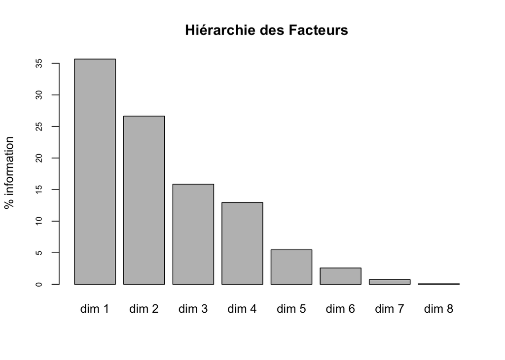

Tableau des valeurs propres

|  | Valeur propre | % variance | % variance cumulée |
| --- | --- | --- | --- |
| dim 1 | 0.65 | 35.67 | 35.67 |
| dim 2 | 0.49 | 26.64 | 62.32 |
| dim 3 | 0.29 | 15.86 | 78.18 |
| dim 4 | 0.24 | 12.94 | 91.12 |
| dim 5 | 0.10 | 5.47 | 96.59 |
| dim 6 | 0.05 | 2.58 | 99.18 |
| dim 7 | 0.01 | 0.74 | 99.91 |
| dim 8 | 0.00 | 0.09 | 100.00 |

### Relation des colonnes avec les facteurs

Relations entre colonnes et facteurs

|  | coo_1 | ctr_1 | cos2_1 | coo_2 | ctr_2 | cos2_2 | coo_3 | ctr_3 | cos2_3 | coo_4 | ctr_4 | cos2_4 |
| --- | --- | --- | --- | --- | --- | --- | --- | --- | --- | --- | --- | --- |
| Fon | -0.38 | 7.56 | 0.20 | -0.63 | 28.81 | 0.56 | 0.02 | 0.05 | 0.00 | -0.42 | 26.12 | 0.25 |
| Adja | -1.39 | 37.51 | 0.50 | 1.38 | 49.75 | 0.50 | 0.01 | 0.00 | 0.00 | 0.00 | 0.00 | 0.00 |
| Yoruba | -0.24 | 1.37 | 0.04 | -0.53 | 8.72 | 0.19 | 0.02 | 0.02 | 0.00 | 1.06 | 71.16 | 0.76 |
| Bariba | 1.11 | 23.81 | 0.63 | 0.47 | 5.69 | 0.11 | -0.70 | 21.35 | 0.25 | -0.08 | 0.36 | 0.00 |
| Peul | 0.75 | 6.87 | 0.49 | 0.30 | 1.46 | 0.08 | -0.12 | 0.38 | 0.01 | 0.06 | 0.11 | 0.00 |
| Ottamari | 0.66 | 2.85 | 0.18 | 0.08 | 0.05 | 0.00 | -0.99 | 14.52 | 0.40 | 0.13 | 0.31 | 0.01 |
| Yoa | 0.92 | 3.50 | 0.13 | 0.25 | 0.34 | 0.01 | 2.08 | 40.18 | 0.64 | 0.22 | 0.56 | 0.01 |
| Dendi | 1.16 | 16.52 | 0.48 | 0.52 | 4.48 | 0.10 | 0.92 | 23.50 | 0.30 | -0.19 | 1.22 | 0.01 |
| Autres | -0.05 | 0.01 | 0.00 | -0.38 | 0.70 | 0.20 | -0.01 | 0.00 | 0.00 | -0.13 | 0.16 | 0.02 |

### Relation des lignes avec les facteurs

En AFC, les lignes et les colonnes jouent un rôle équivalent. Les sorties pour les départements (lignes du tableau de contingence) s’interprètent de la même manière que pour les colonnes. Chaque axe s’interprète en regardant les contributions les plus élevées des points ligne (dep) et des points colonne (langue) à la formation de l’axe.

Relations entre lignes et facteurs

|  | coo_1 | ctr_1 | cos2_1 | coo_2 | ctr_2 | cos2_2 | coo_3 | ctr_3 | cos2_3 | coo_4 | ctr_4 | cos2_4 |
| --- | --- | --- | --- | --- | --- | --- | --- | --- | --- | --- | --- | --- |
| Alibori | 1.22 | 17.50 | 0.60 | 0.57 | 5.12 | 0.13 | 0.21 | 1.14 | 0.02 | -0.18 | 1.09 | 0.01 |
| Atacora | 1.05 | 13.67 | 0.39 | 0.38 | 2.41 | 0.05 | -1.02 | 29.26 | 0.37 | -0.01 | 0.00 | 0.00 |
| Atlantique | -0.23 | 0.94 | 0.15 | -0.42 | 4.39 | 0.52 | 0.04 | 0.08 | 0.01 | -0.33 | 5.31 | 0.31 |
| Borgou | 0.90 | 13.46 | 0.56 | 0.34 | 2.60 | 0.08 | -0.40 | 5.88 | 0.11 | 0.06 | 0.17 | 0.00 |
| Collines | -0.17 | 0.34 | 0.02 | -0.57 | 5.29 | 0.27 | 0.12 | 0.38 | 0.01 | 0.90 | 27.28 | 0.68 |
| Couffo | -1.50 | 26.86 | 0.49 | 1.55 | 38.08 | 0.51 | 0.01 | 0.00 | 0.00 | 0.02 | 0.02 | 0.00 |
| Donga | 1.12 | 10.10 | 0.24 | 0.44 | 2.09 | 0.04 | 1.87 | 63.17 | 0.67 | 0.00 | 0.00 | 0.00 |
| Littoral | -0.13 | 0.26 | 0.07 | -0.38 | 2.94 | 0.57 | -0.04 | 0.04 | 0.00 | -0.06 | 0.13 | 0.01 |
| Mono | -1.11 | 10.15 | 0.53 | 1.03 | 11.78 | 0.46 | -0.01 | 0.00 | 0.00 | -0.05 | 0.06 | 0.00 |
| Oueme | -0.36 | 2.09 | 0.18 | -0.69 | 10.62 | 0.69 | -0.02 | 0.01 | 0.00 | -0.29 | 3.79 | 0.12 |
| Plateau | -0.38 | 1.31 | 0.06 | -0.55 | 3.75 | 0.14 | -0.01 | 0.00 | 0.00 | 1.29 | 42.35 | 0.76 |
| Zou | -0.49 | 3.33 | 0.17 | -0.77 | 10.94 | 0.42 | 0.03 | 0.03 | 0.00 | -0.73 | 19.80 | 0.37 |

## Exercices

### Commentaire des axes 1 et 2

En vous aidant des tableaux précédents, vous devez commentez le plan factoriel des axes 1 et 2 représenté ci-dessous

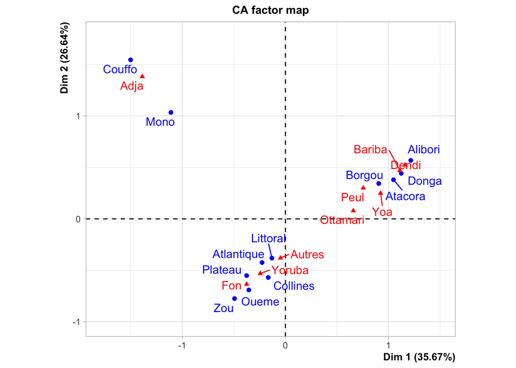

- **Commentaire :** …

### Commentaire des axes 3 et 4

Que pensez-vous des informations supplémentaires apportées par les axes 3 et 4 ?

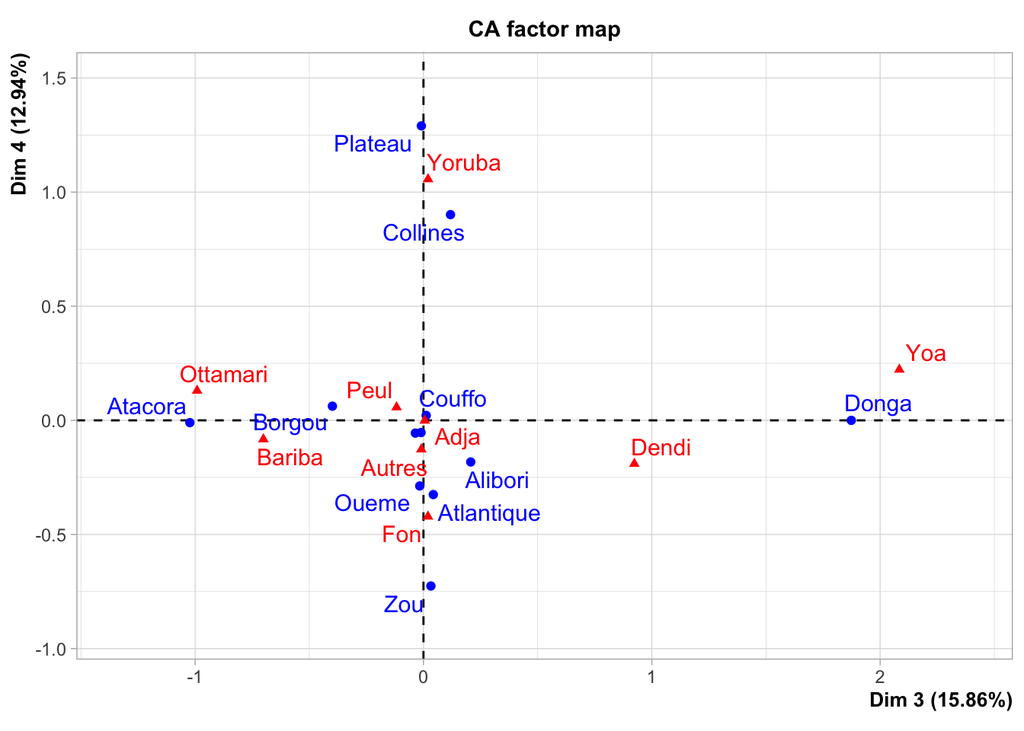

- **Commentaire :** …